# sa2_rmarkdown_example

Daniel Fuller

12/02/2020

```r
knitr::opts_chunk$set(echo = TRUE)
library(tidyverse)
library(pastecs)
library(knitr)
```

## Reading in the data

Need to remove NA too

```r
data <- read_csv("exploring data.csv")
data <- data %>%
          na_if(777) %>%
          na_if(888) %>%
          na_if(999)
```

## Variables

There are 2 main variables of interest

1. `depressionT1` a continuous measure of depression.
- Depression is the dependent variable of this study which was measured using the 20-item Center for Epidemiologic Studies Depression Scale (CES-D; Radloff, 1977). The CES-D is a common measure of depressive symptoms. Respondents are requested to rate the extent to which they experienced 20 symptoms over the past week (eg, “I felt sad”). Items are scored on a 4-point scale, ranging from 0 (rarely or none of the time, less than a day) to 3 (most or all the time, 5–7 days). Scores are computed as the sum of the responses to the items and total scores can range from 0 to 60, with higher scores indicating greater depression symptoms (Time 1: cesd101-cesd120). Scores of 16 or above indicate probable cases of clinical depression.
2. `income1` an ordinal measure of income catories.
- Income is the independent variable in the study. Income was measured from <$5,000 to >$40,000 in $5,000 increments. There were 9 income categories.

### Checking variables just too make sure I have what I think I do.

```r
typeof(data$depressionT1)
```

```
## [1] "double"
```

```r
typeof(data$income1)
```

```
## [1] "double"
```

```r
#data$income1 <- as.integer(data$income1)
#typeof(data$income1)
```

`income1` is type double (a number) not an ordinal variable. We need to recode this to ordinal.

```r
data$income <- as.ordered(data$income1)
typeof(data$income)
```

```
## [1] "integer"
```

## Sample Description

```r
table(data$cgsex)
```

```
##
##   1   2
## 238  71
```

```r
sum(table(data$cgsex))
```

```
## [1] 309
```

```r
summary(data$educ)
```

```
##    Min. 1st Qu.  Median    Mean 3rd Qu.    Max.
##   1.000   4.000   6.000   5.725   7.000   8.000
```

```r
summary(data$income1)
```

```
##    Min. 1st Qu.  Median    Mean 3rd Qu.    Max.    NA's
##   1.000   4.000   6.000   6.075   9.000   9.000      28
```

```r
table(data$mstat1)
```

```
##
##   1   2   3   4   5   6
##  40  12 206   4  26  21
```

```r
table(data$dement1)
```

```
##
##   0   1
## 181 127
```

At Time 1, 77.1% of the caregivers were female. Mean caregiver age was 62.8 (SD = 14.23), and the sample was predominately Caucasian (79.0%). The caregivers in this sample were highly educated, with 60.3% attaining at least some university or college education. Median household income was $25,000 to 30,000 per year (SD = $15,000). Almost half of caregivers were spouses (45.8%) and more than one third (38.7%) were adult children of care recipients. Care recipients had a wide variety of disabling conditions with 41% diagnosed with Alzheimer’s disease or other forms of dementia.

## Descriptive statistics for `depressionT1`

Using functin `stat.desc` from `pastecs` package combined with kable from the `knitr` to make a nice table

```r
kable(stat.desc(data$depressionT1))
```

|  | x |
| --- | --- |
| nbr.val | 297.0000000 |
| nbr.null | 23.0000000 |
| nbr.na | 12.0000000 |
| min | 0.0000000 |
| max | 54.0000000 |
| range | 54.0000000 |
| sum | 3507.0000000 |
| median | 8.0000000 |
| mean | 11.8080808 |
| SE.mean | 0.6128279 |
| CI.mean.0.95 | 1.2060519 |
| var | 111.5407453 |
| std.dev | 10.5612852 |
| coef.var | 0.8944117 |

## Descriptive statistics for `income1`

Income1 is ordinal so doing descriptives like mean is not meaningful. Instead I use frequency tables. For full marks you should recode this to it’s meaningful when displayed.

```r
count <- table(data$income)  # Table of counts
kable(count, format = "markdown") #Display
```

| Var1 | Freq |
| --- | --- |
| 1 | 10 |
| 2 | 16 |
| 3 | 25 |
| 4 | 38 |
| 5 | 41 |
| 6 | 17 |
| 7 | 26 |
| 8 | 23 |
| 9 | 85 |

## Histogram and boxplot for `depressionT1`

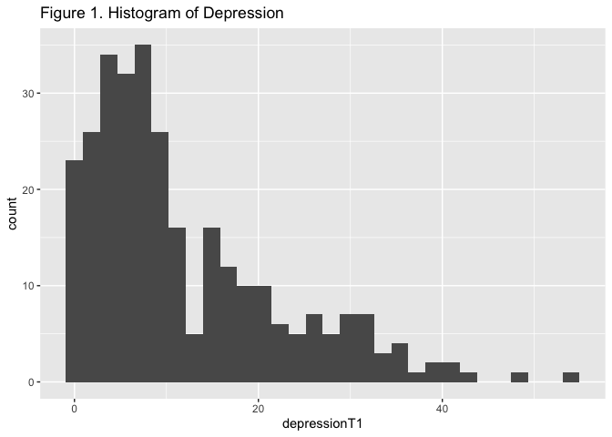

```r
histo_dep <- ggplot(data, aes(depressionT1)) +
                geom_histogram() +
                ggtitle("Figure 1. Histogram of Depression")
plot(histo_dep)
```

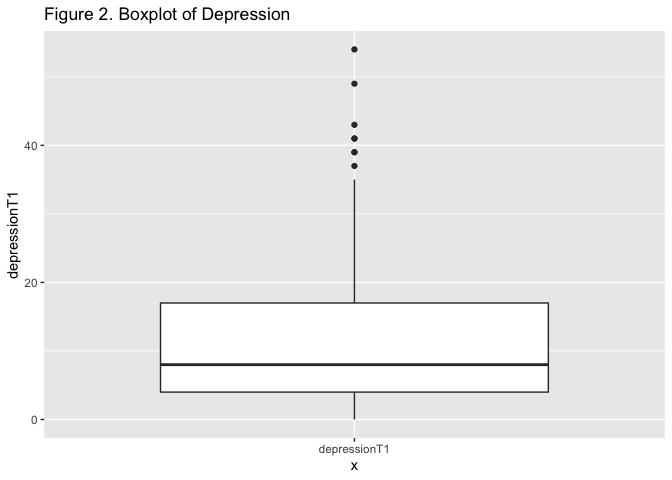

```r
box_dep <- ggplot(data, aes("depressionT1", depressionT1)) +
                geom_boxplot() +
                ggtitle("Figure 2. Boxplot of Depression")
plot(box_dep)
```